## 1. Importing libraries

```python
## Loading libraries
import os
import warnings
warnings.filterwarnings('ignore')
import numpy as np
import pandas as pd
import matplotlib.pyplot as plt
import seaborn as sns
import random
import ast
import lightgbm as lgb
from sklearn.model_selection import StratifiedKFold
from sklearn.preprocessing import LabelEncoder
from sklearn.impute import SimpleImputer
from sklearn.metrics import roc_auc_score, log_loss



# ── Topic parser (defined here so EDA and feature engineering both use it) ──
def parse_topics(topic_str):
    """Parse topics_list (list of lists string) into a flat list of topic strings."""
    if pd.isna(topic_str):
        return []
    try:
        parsed = ast.literal_eval(str(topic_str))
        flat = []
        for item in parsed:
            if isinstance(item, list):
                flat.extend([t.strip() for t in item])
            else:
                flat.append(str(item).strip())
        return flat
    except Exception:
        return [str(topic_str).strip()]
```

### Setting seed

```python
RANDOM_STATE = 42
random.seed(RANDOM_STATE)           # Python built-in random
np.random.seed(RANDOM_STATE)        # NumPy (used by sklearn internally)
os.environ['PYTHONHASHSEED'] = str(RANDOM_STATE)  # Python hash seed
print(f'✅ Imports complete | RANDOM_STATE={RANDOM_STATE} | Seeds set for: random, numpy, os.environ')
```

```
✅ Imports complete | RANDOM_STATE=42 | Seeds set for: random, numpy, os.environ
```

```python
Targets = ['adopted_within_07_days', 'adopted_within_90_days', 'adopted_within_120_days']
Target_labels = ['TX_07', 'TX_90', 'TX_120']  # for submission columns
ID_COL = 'ID'
n_splits = 5
```

## 2. Loading the data

```python
train = pd.read_csv("Train.csv")
test = pd.read_csv("Test.csv")
prior = pd.read_csv("Prior.csv")
sample = pd.read_csv("SampleSubmission.csv")
```

```python
def clean_trainer(val):
    """Extract first trainer from list-formatted string like ['TRA_abc'] or ['TRA_abc', 'TRA_xyz']"""
    if pd.isna(val):
        return val
    try:
        parsed = ast.literal_eval(str(val))
        if isinstance(parsed, list) and len(parsed) > 0:
            return parsed[0]  # take first trainer
    except:
        pass
    return str(val)

train['trainer'] = train['trainer'].apply(clean_trainer)
test['trainer']  = test['trainer'].apply(clean_trainer)
prior['trainer'] = prior['trainer'].apply(clean_trainer)

print("Trainer column after cleaning:")
print(train['trainer'].value_counts().head(10))
```

```
Trainer column after cleaning:
trainer
TRA_gertumxc    3049
TRA_suiifsur    2190
TRA_hyodnntj    2168
TRA_szrwyfzz    2028
TRA_rkvyofbh    1877
TRA_ubcgvofe    1456
TRA_kkzpfdtu     734
TRA_twwcfcum      24
TRA_dttdgplk      10
Name: count, dtype: int64
```

```python
print("Train shape:", train.shape)
print("Test shape:", test.shape)
print("Prior shape:", prior.shape)
```

```
Train shape: (13536, 39)
Test shape: (5621, 36)
Prior shape: (44882, 17)
```

```python
# How many rows vs unique farmers?
print("Prior unique Farmer IDs:", prior['ID'].nunique())
print("Train unique Farmer IDs:", train['ID'].nunique())

# How many prior farmers overlap with train?
overlap = prior['ID'].isin(train['ID']).sum()
print("Prior farmers that appear in Train:", overlap)

# Sample rows
print("\n=== PRIOR SAMPLE ===")
print(prior.head(5).to_string())

# What does topic list look like exactly?
print("\n=== TOPIC LIST SAMPLE (train) ===")
print(train['topics_list'].head(5).to_string())
```

```
Prior unique Farmer IDs: 44882
Train unique Farmer IDs: 13536
Prior farmers that appear in Train: 0

=== PRIOR SAMPLE ===
          ID  farmer_name training_day  gender registration       age   group_name  belong_to_cooperative      county    subcounty          ward  adopted_within_07_days  adopted_within_90_days  adopted_within_120_days  has_topic_trained_on       trainer                                               …
0  ID_70GP6F  FAR_leopgvh   2024-01-03  Female       Manual  Above 35  GRP_yvpakgc                      0  CNT_lpotuu  SUB_lpotuuf  WRD_lpotuufh                       0                       0                        0                     0  TRA_szrwyfzz                                               …
1  ID_IWQOWJ  FAR_vdcjfxm   2024-01-03  Female         Ussd  Above 35  GRP_yvpakgc                      0  CNT_lpotuu  SUB_lpotuuf  WRD_lpotuufh                       0                       0                        0                     0  TRA_szrwyfzz                                               …
2  ID_Z3ES85  FAR_hfkybdg   2024-01-03  Female       Manual  Above 35  GRP_zmblxsw                      0  CNT_fhdsoy  SUB_mdyljqn  WRD_atkhhvon                       0                       0                        0                     1  TRA_rkvyofbh  ['Asili Fertilizer (Organic)', 'Biosecurity I…
3  ID_JNZM6R  FAR_hfkybdg   2024-01-03  Female       Manual  Above 35  GRP_psdrfni                      0  CNT_fhdsoy  SUB_mdyljqn  WRD_atkhhvon                       0                       0                        0                     1  TRA_rkvyofbh                                               …
4  ID_BNJ1GU  FAR_hfkybdg   2024-01-03  Female       Manual  Above 35  GRP_psdrfni                      1  CNT_fhdsoy  SUB_mdyljqn  WRD_atkhhvon                       0                       0                        0                     1  TRA_rkvyofbh                                               …

=== TOPIC LIST SAMPLE (train) ===
0                   [['Ndume App', 'Poultry Feeding']]
1           [['Poultry Housing'], ['Poultry Housing']]
2    [['Asili Fertilizer (Organic)', 'Biosecurity I...
3    [['Poultry Products'], ['Record Keeping In Dai...
4                   [['Ndume App', 'Poultry Feeding']]
```

```python
print("=== TARGET BALANCE ===")
summary = []
for col in Targets:
    total    = len(train[col])
    adopted  = train[col].sum()
    not_adopted = total - adopted
    rate     = adopted / total
    ratio    = not_adopted / adopted  # how many 0s per 1
    summary.append({
        'Target':       col,
        'Total':        total,
        'Adopted (1)':  adopted,
        'Not Adopted (0)': not_adopted,
        'Adoption Rate': f'{rate*100:.2f}%',
        'Imbalance Ratio': f'{ratio:.0f}:1'
    })

display(pd.DataFrame(summary).set_index('Target'))
```

```
=== TARGET BALANCE ===
```

| Target | Total | Adopted (1) | Not Adopted (0) | Adoption Rate | Imbalance Ratio |
| --- | --- | --- | --- | --- | --- |
| adopted_within_07_days | 13536 | 153 | 13383 | 1.13% | 87:1 |
| adopted_within_90_days | 13536 | 214 | 13322 | 1.58% | 62:1 |
| adopted_within_120_days | 13536 | 302 | 13234 | 2.23% | 44:1 |

```python
#Check missing values
print('=== MISSING VALUES IN TRAIN ===')
missing = train.isnull().sum()
print(missing[missing > 0] if missing.any() else 'No missing values')

print('\n=== MISSING VALUES IN TEST ===')
missing_test = test.isnull().sum()
print(missing_test[missing_test > 0] if missing_test.any() else 'No missing values')
```

```
=== MISSING VALUES IN TRAIN ===
No missing values

=== MISSING VALUES IN TEST ===
No missing values
```

```python
# Cardinality of categorical columns
cat_cols = ['gender', 'age', 'registration', 'group_name',
            'county', 'subcounty', 'ward', 'trainer']
print('=== CARDINALITY ===')
for col in cat_cols:
    if col in train.columns:
        print(f'{col:25s}: {train[col].nunique():5d} unique values')
```

```
=== CARDINALITY ===
gender                   :     2 unique values
age                      :     2 unique values
registration             :     2 unique values
group_name               :   864 unique values
county                   :     8 unique values
subcounty                :    26 unique values
ward                     :    66 unique values
trainer                  :     9 unique values
```

```python
def parse_topics(topic_str):
    """Parse topics_list string into a flat list of topic strings."""
    if pd.isna(topic_str):
        return []
    try:
        parsed = ast.literal_eval(str(topic_str))
        # Handle list of lists: [['topic1', 'topic2'], ['topic3']]
        if isinstance(parsed, list):
            flat = []
            for item in parsed:
                if isinstance(item, list):
                    flat.extend([t.strip() for t in item])
                else:
                    flat.append(str(item).strip())
            return flat
    except Exception:
        pass
    # Fallback: treat as plain string
    return [str(topic_str).strip()]


def engineer_topic_features(df, topic_col='topics_list'):
    """Extract numeric features from the topics_list column."""
    topics_parsed = df[topic_col].apply(parse_topics)

    df = df.copy()
    df['topic_total_count']  = topics_parsed.apply(len)
    df['topic_unique_count'] = topics_parsed.apply(lambda x: len(set(x)))
    df['topic_sessions']     = df[topic_col].apply(
        lambda x: len(ast.literal_eval(str(x))) if pd.notna(x) else 0
    )
    df['topic_repeat_rate']  = df['topic_total_count'] - df['topic_unique_count']

    # Get all topics across train+test for one-hot encoding
    return df, topics_parsed


def get_top_topics(train_parsed, top_n=20):
    """Find the most common topics in the training set."""
    from collections import Counter
    all_topics = [t for topics in train_parsed for t in topics]
    counter    = Counter(all_topics)
    top_topics = [t for t, _ in counter.most_common(top_n)]
    print(f'Top {top_n} topics:')
    for t, c in counter.most_common(top_n):
        print(f'  {c:5d}x  {t}')
    return top_topics


def add_topic_dummies(df, topics_parsed, top_topics):
    """Add binary columns for each top topic."""
    df = df.copy()
    for topic in top_topics:
        col_name = 'topic_' + topic.lower().replace(' ', '_').replace('(', '').replace(')', '').replace('.', '')[:40]
        df[col_name] = topics_parsed.apply(lambda x: int(topic in x))
    return df


# Apply to train
train, train_topics_parsed = engineer_topic_features(train)
top_topics = get_top_topics(train_topics_parsed, top_n=20)
train = add_topic_dummies(train, train_topics_parsed, top_topics)

# Apply to test
test, test_topics_parsed = engineer_topic_features(test)
test = add_topic_dummies(test, test_topics_parsed, top_topics)

print(f'\nTrain shape after topic features: {train.shape}')
```

```
Top 20 topics:
   1657x  The Benefits Of Ndume App
   1294x  Herd Health Management.
   1247x  Biosecurity In Poultry Farming
   1246x  Feeding A Lactating Cow
   1193x  Calf Feeding
   1153x  Poultry Management Practises.
   1091x  Poultry Health Management.
    966x  Dairy Feed Management
    934x  Poultry Diseases And Biosecurity
    930x  Record Keeping In Poultry
    894x  Dairy Health Management
    855x  Milking Hygiene
    855x  Poultry Health Management
    854x  Poultry Management Practices
    850x  How To Succeed In Breeding
    823x  Diseases In Dairy Farming
    823x  Poultry Management Practises..
    821x  Poultry Housing
    806x  Dairy Housing
    788x  Record Keeping In Dairy

Train shape after topic features: (13536, 39)
```

#### Adoption rates (%) per category

```python
for col in ['gender', 'age', 'registration', 'belong_to_cooperative']:
    print(f"\n=== {col} ===")
    display(train.groupby(col)[TARGETS].mean().round(3) * 100)
```

```
=== gender ===
```

| gender | adopted_within_07_days | adopted_within_90_days | adopted_within_120_days |
| --- | --- | --- | --- |
| Female | 1.1 | 1.5 | 2.2 |
| Male | 1.3 | 1.8 | 2.4 |

```
=== age ===
```

| age | adopted_within_07_days | adopted_within_90_days | adopted_within_120_days |
| --- | --- | --- | --- |
| Above 35 | 1.1 | 1.5 | 2.2 |
| Below 35 | 1.4 | 2.0 | 2.5 |

```
=== registration ===
```

| registration | adopted_within_07_days | adopted_within_90_days | adopted_within_120_days |
| --- | --- | --- | --- |
| Manual | 0.7 | 0.8 | 1.0 |
| Ussd | 1.4 | 2.1 | 3.0 |

```
=== belong_to_cooperative ===
```

| belong_to_cooperative | adopted_within_07_days | adopted_within_90_days | adopted_within_120_days |
| --- | --- | --- | --- |
| 0 | 0.9 | 1.4 | 2.0 |
| 1 | 2.4 | 2.6 | 3.6 |

##### **Gender:** Males adopt slightly more than females across all time windows (1.3% vs 1.1% at 7 days, 1.8% vs 1.5% at 90 days). The difference is small though

##### **Age:** Younger farmers (Below 35) adopt at a consistently higher rate than older ones (1.4% vs 1.1% at 7 days, 2.5% vs 2.2% at 120 days). Moderate signal.

```python
print(train['trainer'].value_counts().head(20))
print("\nRows where trainer looks like a list:")
print(train[train['trainer'].str.startswith('[')]['trainer'].value_counts().head(10))
print("\nTotal multi-trainer rows:", train['trainer'].str.startswith('[').sum())
```

```
trainer
TRA_gertumxc    3049
TRA_suiifsur    2190
TRA_hyodnntj    2168
TRA_szrwyfzz    2028
TRA_rkvyofbh    1877
TRA_ubcgvofe    1456
TRA_kkzpfdtu     734
TRA_twwcfcum      24
TRA_dttdgplk      10
Name: count, dtype: int64

Rows where trainer looks like a list:
Series([], Name: count, dtype: int64)

Total multi-trainer rows: 0
```

```
Trainers with 20+ farmers: 8

Top 10 trainers by 7-day adoption rate:
```

|  | trainer | farmer_count | rate_07 | rate_90 | rate_120 |
| --- | --- | --- | --- | --- | --- |
| 0 | TRA_twwcfcum | 24 | 4.167 | 4.167 | 4.167 |
| 1 | TRA_kkzpfdtu | 734 | 3.815 | 4.223 | 5.313 |
| 2 | TRA_rkvyofbh | 1877 | 2.877 | 3.197 | 3.676 |
| 3 | TRA_szrwyfzz | 2028 | 1.923 | 3.600 | 4.635 |
| 4 | TRA_hyodnntj | 2168 | 0.830 | 0.876 | 2.906 |
| 5 | TRA_gertumxc | 3049 | 0.361 | 0.689 | 0.787 |
| 6 | TRA_suiifsur | 2190 | 0.091 | 0.137 | 0.137 |
| 7 | TRA_ubcgvofe | 1456 | 0.000 | 0.412 | 0.618 |

```
Adoption rate distribution across trainers:
```

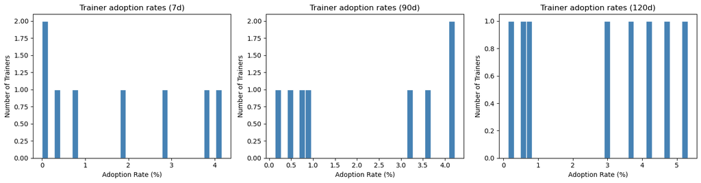

```python
# ── 3.5 Trainer Effectiveness ────────────────────────────────
# Some trainers may be significantly better at driving adoption
trainer_stats = train.groupby('trainer').agg(
    farmer_count=('ID', 'count'),
    rate_07=('adopted_within_07_days', 'mean'),
    rate_90=('adopted_within_90_days', 'mean'),
    rate_120=('adopted_within_120_days', 'mean')
).reset_index()

# Only look at trainers with enough farmers to be meaningful
trainer_stats = trainer_stats[trainer_stats['farmer_count'] >= 20].copy()
trainer_stats[['rate_07','rate_90','rate_120']] *= 100

print(f'Trainers with 20+ farmers: {len(trainer_stats)}')
print('\nTop 10 trainers by 7-day adoption rate:')
display(trainer_stats.sort_values('rate_07', ascending=False).head(10)
        .round(3).reset_index(drop=True))

print('\nAdoption rate distribution across trainers:')
fig, axes = plt.subplots(1, 3, figsize=(15, 4))
for i, (col, label) in enumerate(zip(['rate_07','rate_90','rate_120'], ['7d','90d','120d'])):
    axes[i].hist(trainer_stats[col], bins=30, color='steelblue', edgecolor='white')
    axes[i].set_title(f'Trainer adoption rates ({label})')
    axes[i].set_xlabel('Adoption Rate (%)')
    axes[i].set_ylabel('Number of Trainers')
plt.tight_layout()
plt.show()
```

```
Counties with 20+ farmers: 8

Top 10 counties by 7-day adoption rate:
```

|  | county | farmer_count | rate_07 | rate_90 | rate_120 |
| --- | --- | --- | --- | --- | --- |
| 0 | CNT_mvqqmw | 734 | 3.815 | 4.223 | 5.313 |
| 1 | CNT_hfhimd | 30 | 3.333 | 3.333 | 3.333 |
| 2 | CNT_fhdsoy | 1887 | 2.862 | 3.180 | 3.657 |
| 3 | CNT_lpotuu | 2028 | 1.923 | 3.600 | 4.635 |
| 4 | CNT_mggvna | 2168 | 0.830 | 0.876 | 2.906 |
| 5 | CNT_vvuukv | 3049 | 0.361 | 0.689 | 0.787 |
| 6 | CNT_yljqnl | 2190 | 0.091 | 0.137 | 0.137 |
| 7 | CNT_rihpna | 1450 | 0.000 | 0.414 | 0.621 |

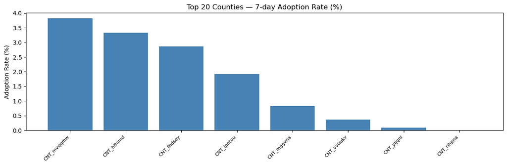

```python
#  3.6 Geographic Adoption Patterns
county_stats = train.groupby('county').agg(
    farmer_count=('ID', 'count'),
    rate_07=('adopted_within_07_days', 'mean'),
    rate_90=('adopted_within_90_days', 'mean'),
    rate_120=('adopted_within_120_days', 'mean')
).reset_index()

county_stats = county_stats[county_stats['farmer_count'] >= 20].copy()
county_stats[['rate_07','rate_90','rate_120']] *= 100

print(f'Counties with 20+ farmers: {len(county_stats)}')
print('\nTop 10 counties by 7-day adoption rate:')
display(county_stats.sort_values('rate_07', ascending=False).head(10)
        .round(3).reset_index(drop=True))

# Visualise spread
fig, ax = plt.subplots(figsize=(12, 4))
county_sorted = county_stats.sort_values('rate_07', ascending=False).head(20)
ax.bar(range(len(county_sorted)), county_sorted['rate_07'], color='steelblue')
ax.set_xticks(range(len(county_sorted)))
ax.set_xticklabels(county_sorted['county'], rotation=45, ha='right', fontsize=8)
ax.set_title('Top 20 Counties: 7-day Adoption Rate (%)')
ax.set_ylabel('Adoption Rate (%)')
plt.tight_layout()
plt.show()
```

```
Top 15 topics by 7-day adoption rate (min 20 farmers):
```

|  | topic | count | rate_07 | rate_90 | rate_120 |
| --- | --- | --- | --- | --- | --- |
| 0 | Poultry Health With Biodeal | 74 | 22.973 | 24.324 | 24.324 |
| 1 | Livestock Management Practices | 40 | 17.500 | 17.500 | 17.500 |
| 2 | Importance Of Mineral Supplementation | 239 | 10.460 | 10.879 | 10.879 |
| 3 | Pest And Diseases At Harvesting Stage | 37 | 8.108 | 8.108 | 8.108 |
| 4 | Herd. Health. Management | 481 | 7.692 | 10.811 | 11.642 |
| 5 | Dairy Nutrition With Tyari | 185 | 7.027 | 7.568 | 7.568 |
| 6 | Poultry Feeding With Tyari | 209 | 6.220 | 6.699 | 6.699 |
| 7 | Control Of External Parasites With Dominex. | 49 | 6.122 | 6.122 | 6.122 |
| 8 | Poultry Health Management. Practices | 446 | 5.830 | 8.072 | 9.193 |
| 9 | Deworming And Record Keeping In Animal Health | 423 | 5.674 | 10.875 | 13.948 |
| 10 | Poultry Management. Practices | 149 | 5.369 | 5.369 | 5.369 |
| 11 | Why You Should Vaccinate Your Animals | 425 | 5.176 | 11.059 | 13.412 |
| 12 | Diseases In Dairy Farming | 739 | 4.601 | 5.142 | 11.096 |
| 13 | Dairy Health Management | 805 | 4.348 | 4.845 | 10.311 |
| 14 | Poultry Health Management | 772 | 4.275 | 4.922 | 10.492 |

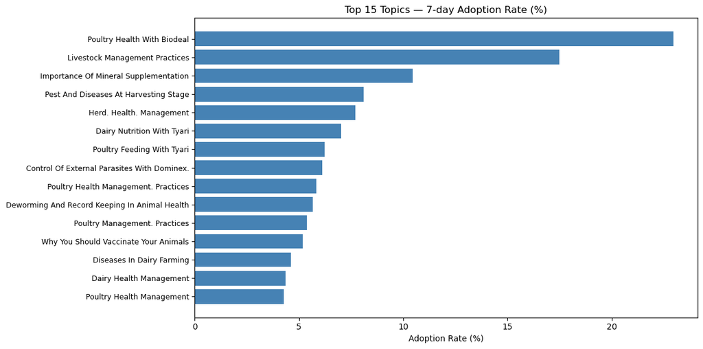

```python
# ── 3.7 Topic Adoption Rates ─────────────────────────────────
# Parse topics now (before full feature engineering) just for EDA
import ast
from collections import Counter

def parse_topics_flat(topic_str):
    if pd.isna(topic_str): return []
    try:
        parsed = ast.literal_eval(str(topic_str))
        flat = []
        for item in parsed:
            if isinstance(item, list): flat.extend([t.strip() for t in item])
            else: flat.append(str(item).strip())
        return list(set(flat))  # deduplicate within farmer
    except: return []

train_topics = train['topics_list'].apply(parse_topics_flat)

# Build topic x adoption dataframe
all_topics = list(set(t for topics in train_topics for t in topics))
topic_records = []
for topic in all_topics:
    mask  = train_topics.apply(lambda x: topic in x)
    count = mask.sum()
    if count < 20: continue  # skip rare topics
    topic_records.append({
        'topic':    topic,
        'count':    count,
        'rate_07':  train.loc[mask, 'adopted_within_07_days'].mean() * 100,
        'rate_90':  train.loc[mask, 'adopted_within_90_days'].mean() * 100,
        'rate_120': train.loc[mask, 'adopted_within_120_days'].mean() * 100,
    })

topic_df = pd.DataFrame(topic_records).sort_values('rate_07', ascending=False)
print('Top 15 topics by 7-day adoption rate (min 20 farmers):')
display(topic_df.head(15).round(3).reset_index(drop=True))

# Plot
fig, ax = plt.subplots(figsize=(12, 6))
top15 = topic_df.head(15)
ax.barh(range(len(top15)), top15['rate_07'], color='steelblue')
ax.set_yticks(range(len(top15)))
ax.set_yticklabels(top15['topic'], fontsize=9)
ax.invert_yaxis()
ax.set_title('Top 15 Topics — 7-day Adoption Rate (%)')
ax.set_xlabel('Adoption Rate (%)')
plt.tight_layout()
plt.show()
```

```
=== TARGET CORRELATION MATRIX ===
```

|  | adopted_within_07_days | adopted_within_90_days | adopted_within_120_days |
| --- | --- | --- | --- |
| adopted_within_07_days | 1.000 | 0.844 | 0.708 |
| adopted_within_90_days | 0.844 | 1.000 | 0.839 |
| adopted_within_120_days | 0.708 | 0.839 | 1.000 |

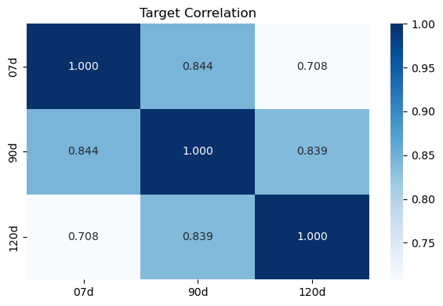

```
=== TARGET OVERLAP ===
Adopted at 7d  → also at 90d  : 100.0%
Adopted at 7d  → also at 120d : 100.0%
Adopted at 90d → also at 120d : 100.0%
Adopted at 120d but NOT at 7d : 149 farmers

→ High overlap = cascade targets is a strong improvement to implement
```

```python
# ── 3.8 Target Correlation ───────────────────────────────────
# Are the 3 targets correlated? If so, cascade targets can improve predictions.
print('=== TARGET CORRELATION MATRIX ===')
corr = train[TARGETS].corr().round(3)
display(corr)

# Visualise
fig, ax = plt.subplots(figsize=(6, 4))
sns.heatmap(corr, annot=True, fmt='.3f', cmap='Blues', ax=ax,
            xticklabels=['07d','90d','120d'],
            yticklabels=['07d','90d','120d'])
ax.set_title('Target Correlation')
plt.tight_layout()
plt.show()

# Key overlap stats
adopted_07  = train['adopted_within_07_days'] == 1
adopted_90  = train['adopted_within_90_days'] == 1
adopted_120 = train['adopted_within_120_days'] == 1

print('\n=== TARGET OVERLAP ===')
print(f'Adopted at 7d  → also at 90d  : {train.loc[adopted_07,  "adopted_within_90_days"].mean()*100:.1f}%')
print(f'Adopted at 7d  → also at 120d : {train.loc[adopted_07,  "adopted_within_120_days"].mean()*100:.1f}%')
print(f'Adopted at 90d → also at 120d : {train.loc[adopted_90,  "adopted_within_120_days"].mean()*100:.1f}%')
print(f'Adopted at 120d but NOT at 7d : {train.loc[adopted_120 & ~adopted_07, "ID"].count()} farmers')
print('\n→ High overlap = cascade targets is a strong improvement to implement')
```

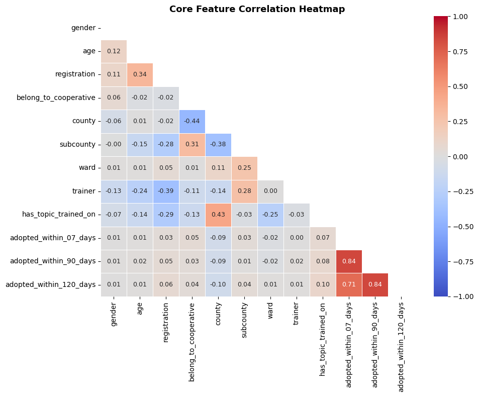

```python
# ── Focused correlation: core features vs targets only ───────
core_cols = ['gender', 'age', 'registration', 'belong_to_cooperative',
             'county', 'subcounty', 'ward', 'trainer',
             'has_topic_trained_on',
             'adopted_within_07_days', 'adopted_within_90_days', 'adopted_within_120_days']

train_corr = train[[c for c in core_cols if c in train.columns]].copy()

le = LabelEncoder()
for col in train_corr.select_dtypes(include='object').columns:
    train_corr[col] = le.fit_transform(train_corr[col].astype(str))

plt.figure(figsize=(10, 8))
corr_matrix = train_corr.corr()
mask = np.triu(np.ones_like(corr_matrix, dtype=bool))
sns.heatmap(corr_matrix, mask=mask, annot=True, fmt='.2f',
            cmap='coolwarm', center=0, vmin=-1, vmax=1,
            linewidths=0.5, annot_kws={'size': 9})
plt.title('Core Feature Correlation Heatmap', fontsize=13, fontweight='bold')
plt.tight_layout()
plt.show()
```

#### Feature-to-feature correlations (the redundancy check):

##### **registration** and **age (0.340):** moderately correlated. Younger farmers tend to register via USSD, older ones manually. Not redundant, just related.

##### **registration** and **trainer (-0.387):** notable. Certain trainers tend to attract USSD-registered farmers. Not redundant but worth knowing.

##### **registration** and **subcounty (-0.275):** similar pattern, certain subcounties have more USSD farmers.

##### **belong_to_cooperative** and **county (-0.442):** the strongest feature-to-feature correlation. Cooperative membership varies significantly by county. This makes geographic sense as some counties have stronger cooperative cultures.

##### **county** and **has_topic_trained_on (0.430):** strong. Certain counties have farmers who are more likely to have prior topic training. This is expected since county and trainer are nearly the same thing, and certain trainers are more thorough.

##### **subcounty** and **belong_to_cooperative (0.308):** moderate, same geographic cooperative pattern.

```python
# ── 4.2 Topic Features ───────────────────────────────────────
# parse_topics() is defined in the imports cell — no need to redefine here
from collections import Counter

def engineer_topic_features(df, top_topics, topic_col='topics_list'):
    """Extract numeric + binary topic features."""
    topics_parsed = df[topic_col].apply(parse_topics)
    df = df.copy()

    # Count/diversity features
    df['topic_total_count']     = topics_parsed.apply(len)
    df['topic_unique_count']    = topics_parsed.apply(lambda x: len(set(x)))
    df['topic_repeat_count']    = df['topic_total_count'] - df['topic_unique_count']
    df['topic_sessions']        = df[topic_col].apply(
        lambda x: len(ast.literal_eval(str(x))) if pd.notna(x) else 0
    )
    df['topic_diversity_ratio'] = df['topic_unique_count'] / (df['topic_total_count'] + 1)

    # Binary flag for each top topic
    for topic in top_topics:
        col_name = 'topic_' + topic.lower().replace(' ','_').replace('(','').replace(')','').replace('.','').replace(',','')[:45]
        df[col_name] = topics_parsed.apply(lambda x: int(topic in x))

    return df


# Fit top topics on train only — never let test influence which topics are selected
train_topics_parsed = train['topics_list'].apply(parse_topics)
all_topics          = [t for topics in train_topics_parsed for t in topics]
top_topics          = [t for t, _ in Counter(all_topics).most_common(25)]
print(f'Top 25 topics selected for binary features:')
for t, c in Counter(all_topics).most_common(25):
    print(f'  {c:5d}x  {t}')

train = engineer_topic_features(train, top_topics)
test  = engineer_topic_features(test,  top_topics)
print(f'\nTrain shape after topic features: {train.shape}')
```

```
Top 25 topics selected for binary features:
   1657x  The Benefits Of Ndume App
   1294x  Herd Health Management.
   1247x  Biosecurity In Poultry Farming
   1246x  Feeding A Lactating Cow
   1193x  Calf Feeding
   1153x  Poultry Management Practises.
   1091x  Poultry Health Management.
    966x  Dairy Feed Management
    934x  Poultry Diseases And Biosecurity
    930x  Record Keeping In Poultry
    894x  Dairy Health Management
    855x  Milking Hygiene
    855x  Poultry Health Management
    854x  Poultry Management Practices
    850x  How To Succeed In Breeding
    823x  Diseases In Dairy Farming
    823x  Poultry Management Practises..
    821x  Poultry Housing
    806x  Dairy Housing
    788x  Record Keeping In Dairy
    788x  Aflatoxin In Dairy Farming
    785x  Personal Protective Equipment (Ppe)
    736x  Antimicrobial Resistance
    692x  Poultry Health Management..
    632x  Infertility In Dairy Cows

Train shape after topic features: (13536, 45)
```

```python
# ── 4.3 Prior Rates from Prior.csv ───────────────────────────
# Compute historical adoption rates per group from Prior.
# Used for: trainer, group_name, county, subcounty, ward

def compute_prior_rates(prior_df, group_col, targets):
    """Compute mean adoption rate and count per group from Prior."""
    agg   = {t: ['mean', 'count'] for t in targets if t in prior_df.columns}
    rates = prior_df.groupby(group_col).agg(agg)
    rates.columns = [f'prior_{group_col}_{t}_{stat}'
                     for t, stat in rates.columns]
    return rates.reset_index()


prior_rate_dfs = {}
for col in ['trainer', 'group_name', 'county', 'subcounty', 'ward']:
    if col in prior.columns:
        rates = compute_prior_rates(prior, col, TARGETS)
        prior_rate_dfs[col] = rates
        print(f'Prior rates for {col}: {rates.shape[0]} groups, {rates.shape[1]-1} features')

for col, rates_df in prior_rate_dfs.items():
    train = train.merge(rates_df, on=col, how='left')
    test  = test.merge(rates_df,  on=col, how='left')

print(f'\nTrain shape after prior features: {train.shape}')
print(f'Test  shape after prior features: {test.shape}')
```

```
Prior rates for trainer: 9 groups, 6 features
Prior rates for group_name: 840 groups, 6 features
Prior rates for county: 9 groups, 6 features
Prior rates for subcounty: 28 groups, 6 features
Prior rates for ward: 72 groups, 6 features

Train shape after prior features: (13536, 75)
Test  shape after prior features: (5621, 72)
```

```python
# ── 4.4 Date Features ────────────────────────────────────────
def engineer_date_features(df, date_col='training_day'):
    df = df.copy()
    df[date_col]        = pd.to_datetime(df[date_col], errors='coerce')
    df['day_of_week']   = df[date_col].dt.dayofweek   # 0=Monday
    df['month']         = df[date_col].dt.month
    df['quarter']       = df[date_col].dt.quarter
    df['is_weekend']    = (df[date_col].dt.dayofweek >= 5).astype(int)
    df['day_of_year']   = df[date_col].dt.dayofyear
    return df

train = engineer_date_features(train)
test  = engineer_date_features(test)
print('Date features added.')
```

```
Date features added.
```

### Preprocessing

```python
# ── 5.1 Drop identifiers, separate targets ───────────────────
DROP_COLS = ['farmer_name', 'training_day', 'topics_list']

train_ids = train[ID_COL].copy()
test_ids  = test[ID_COL].copy()
y_dict    = {t: train[t].values for t in Targets}

drop_train = DROP_COLS + [ID_COL] + TARGETS
drop_test  = DROP_COLS + [ID_COL]

X_train_df = train.drop(columns=[c for c in drop_train if c in train.columns])
X_test_df  = test.drop(columns=[c for c in drop_test  if c in test.columns])
X_test_df  = X_test_df.reindex(columns=X_train_df.columns)

print(f'Features before encoding: {X_train_df.shape[1]}')
print(f'Remaining categoricals: {X_train_df.select_dtypes(include="object").columns.tolist()}')
```

```
Features before encoding: 73
Remaining categoricals: ['gender', 'registration', 'age', 'group_name', 'county', 'subcounty', 'ward', 'trainer']
```

```python
# ── 5.2 Target encode all high-cardinality columns ──────────
# Replaces each category value with its mean adoption rate.
# Applied to: trainer, group_name, county, subcounty, ward
# Fitted on full train here; will be recomputed per fold inside CV to avoid leakage.

TARGET_ENCODE_COLS = ['trainer', 'group_name', 'county', 'subcounty', 'ward']
global_mean = {t: y_dict[t].mean() for t in TARGETS}
te_maps = {}  # stores encoding maps for use in CV folds

for col in TARGET_ENCODE_COLS:
    if col not in X_train_df.columns:
        continue
    te_maps[col] = {}
    for target in TARGETS:
        temp     = pd.DataFrame({'col': X_train_df[col], 'target': y_dict[target]})
        rate_map = temp.groupby('col')['target'].mean().to_dict()
        te_maps[col][target] = rate_map
        col_name = f'te_{col}_{target}'
        X_train_df[col_name] = X_train_df[col].map(rate_map).fillna(global_mean[target])
        X_test_df[col_name]  = X_test_df[col].map(rate_map).fillna(global_mean[target])
    # Drop original column — replaced by 3 target-encoded versions
    X_train_df = X_train_df.drop(columns=[col])
    X_test_df  = X_test_df.drop(columns=[col])
    print(f'Target encoded: {col} → {[f"te_{col}_{t[-2:]}d" for t in TARGETS]}')

print(f'\nFeatures after target encoding: {X_train_df.shape[1]}')
```

```
Target encoded: trainer → ['te_trainer_ysd', 'te_trainer_ysd', 'te_trainer_ysd']
Target encoded: group_name → ['te_group_name_ysd', 'te_group_name_ysd', 'te_group_name_ysd']
Target encoded: county → ['te_county_ysd', 'te_county_ysd', 'te_county_ysd']
Target encoded: subcounty → ['te_subcounty_ysd', 'te_subcounty_ysd', 'te_subcounty_ysd']
Target encoded: ward → ['te_ward_ysd', 'te_ward_ysd', 'te_ward_ysd']

Features after target encoding: 83
```

```python
# ── 5.3 Label encode remaining categoricals ──────────────────
# Only low-cardinality columns remain: gender, age, registration
cat_cols = X_train_df.select_dtypes(include=['object','category']).columns.tolist()
print(f'Label encoding: {cat_cols}')

le = LabelEncoder()
for col in cat_cols:
    combined = pd.concat([X_train_df[col], X_test_df[col]]).astype(str).fillna('MISSING')
    le.fit(combined)
    X_train_df[col] = le.transform(X_train_df[col].astype(str).fillna('MISSING'))
    X_test_df[col]  = le.transform(X_test_df[col].astype(str).fillna('MISSING'))

# Convert booleans
for col in X_train_df.select_dtypes(include='bool').columns:
    X_train_df[col] = X_train_df[col].astype(int)
    X_test_df[col]  = X_test_df[col].astype(int)

# ── 5.4 Impute missing values ────────────────────────────────
# Missing values mainly come from prior rate features where
# a trainer/group in train doesn't appear in prior
imputer = SimpleImputer(strategy='median')
X_train = imputer.fit_transform(X_train_df)
X_test  = imputer.transform(X_test_df)

feature_names = X_train_df.columns.tolist()
print(f'\n✅ Final feature matrix: {X_train.shape}')
print(f'Features: {feature_names}')
```

```
Label encoding: ['gender', 'registration', 'age']

✅ Final feature matrix: (13536, 83)
Features: ['gender', 'registration', 'age', 'belong_to_cooperative', 'has_topic_trained_on', 'topic_total_count', 'topic_unique_count', 'topic_sessions', 'topic_repeat_rate', 'topic_the_benefits_of_ndume_app', 'topic_herd_health_management', 'topic_biosecurity_in_poultry_farming', 'topic_feeding_a_l…
```

### Model Training

```python
import lightgbm as lgb

# ── LightGBM parameters ──────────────────────────────────────
LGB_PARAMS = {
    'objective':        'binary',
    'metric':           ['auc', 'binary_logloss'],
    'boosting_type':    'gbdt',
    'n_estimators':     1000,
    'learning_rate':    0.05,
    'max_depth':        6,
    'num_leaves':       31,
    'min_child_samples': 20,
    'subsample':        0.8,
    'colsample_bytree': 0.8,
    'reg_alpha':        0.1,
    'reg_lambda':       0.1,
    'is_unbalance':     True,   # handles class imbalance natively
    'random_state':     RANDOM_STATE,
    'verbose':          -1,
    'n_jobs':           -1,
}


def train_lgb(X, y, target_name):
    """
    Train LightGBM with 5-fold stratified CV.
    Returns OOF predictions, OOF metrics, and full-data model for test inference.
    """
    print(f'\n{"+"*60}')
    print(f'Target: {target_name}  |  Adoption rate: {y.mean()*100:.2f}%')
    print(f'Positives: {int(y.sum())} / {len(y)}')

    kf        = StratifiedKFold(n_splits=N_SPLITS, shuffle=True, random_state=RANDOM_STATE)
    oof_preds = np.zeros(len(y))
    fold_aucs, fold_lls = [], []

    for fold, (tr_idx, val_idx) in enumerate(kf.split(X, y)):
        X_tr, X_val = X[tr_idx], X[val_idx]
        y_tr, y_val = y[tr_idx], y[val_idx]

        model = lgb.LGBMClassifier(**LGB_PARAMS)
        model.fit(
            X_tr, y_tr,
            eval_set=[(X_val, y_val)],
            callbacks=[lgb.early_stopping(50, verbose=False),
                       lgb.log_evaluation(period=-1)]
        )

        preds = model.predict_proba(X_val)[:, 1]
        oof_preds[val_idx] = preds

        auc = roc_auc_score(y_val, preds)
        ll  = log_loss(y_val, preds)
        fold_aucs.append(auc)
        fold_lls.append(ll)
        print(f'  Fold {fold+1}: AUC={auc:.4f}  LogLoss={ll:.4f}  Best iter={model.best_iteration_}')

    oof_auc = roc_auc_score(y, oof_preds)
    oof_ll  = log_loss(y, oof_preds)
    print(f'  ✅ OOF AUC:     {oof_auc:.4f} ± {np.std(fold_aucs):.4f}')
    print(f'  ✅ OOF LogLoss: {oof_ll:.4f} ± {np.std(fold_lls):.4f}')

    # Retrain on full data using mean best iteration from CV folds
    print('  Retraining on full data...')
    full_params = LGB_PARAMS.copy()
    full_params['n_estimators'] = model.best_iteration_
    full_model = lgb.LGBMClassifier(**full_params)
    full_model.fit(X, y)

    return oof_preds, oof_auc, oof_ll, full_model


# ── Train with cascading ─────────────────────────────────────
# TX_07: no cascade — trained on base features only
# TX_90: add TX_07 OOF as extra feature
# TX_120: add TX_07 + TX_90 OOF as extra features

results  = {}
models   = {}
oof_dict = {}   # stores OOF preds for cascading
pred_dict = {}  # stores test preds for cascading

for i, target in enumerate(TARGETS):
    # Build feature matrix for this target (add cascade features if needed)
    if i == 0:
        X_tr = X_train.copy()
        X_te = X_test.copy()
    elif i == 1:
        # Add TX_07 OOF as feature
        X_tr = np.column_stack([X_train, oof_dict[TARGETS[0]]])
        X_te = np.column_stack([X_test,  pred_dict[TARGETS[0]]])
        print(f'  Added cascade feature: {TARGETS[0]} predictions')
    else:
        # Add TX_07 and TX_90 OOF as features
        X_tr = np.column_stack([X_train, oof_dict[TARGETS[0]], oof_dict[TARGETS[1]]])
        X_te = np.column_stack([X_test,  pred_dict[TARGETS[0]], pred_dict[TARGETS[1]]])
        print(f'  Added cascade features: {TARGETS[0]} + {TARGETS[1]} predictions')

    oof, auc, ll, model = train_lgb(X_tr, y_dict[target], target)

    results[target]   = {'oof': oof, 'auc': auc, 'logloss': ll}
    models[target]    = model
    oof_dict[target]  = oof
    pred_dict[target] = model.predict_proba(X_te)[:, 1]
```

```
++++++++++++++++++++++++++++++++++++++++++++++++++++++++++++
Target: adopted_within_07_days  |  Adoption rate: 1.13%
Positives: 153 / 13536
  Fold 1: AUC=0.9472  LogLoss=0.0481  Best iter=1
  Fold 2: AUC=0.9634  LogLoss=0.0510  Best iter=1
  Fold 3: AUC=0.9858  LogLoss=0.0439  Best iter=2
  Fold 4: AUC=0.9944  LogLoss=0.0419  Best iter=8
  Fold 5: AUC=0.9797  LogLoss=0.0446  Best iter=1
  ✅ OOF AUC:     0.9783 ± 0.0169
  ✅ OOF LogLoss: 0.0459 ± 0.0032
  Retraining on full data...
  Added cascade feature: adopted_within_07_days predictions

++++++++++++++++++++++++++++++++++++++++++++++++++++++++++++
Target: adopted_within_90_days  |  Adoption rate: 1.58%
Positives: 214 / 13536
  Fold 1: AUC=0.9855  LogLoss=0.0528  Best iter=3
  Fold 2: AUC=0.9864  LogLoss=0.0527  Best iter=3
  Fold 3: AUC=0.9802  LogLoss=0.0565  Best iter=2
  Fold 4: AUC=0.9421  LogLoss=0.0575  Best iter=2
  Fold 5: AUC=0.9750  LogLoss=0.0572  Best iter=3
  ✅ OOF AUC:     0.9755 ± 0.0164
  ✅ OOF LogLoss: 0.0554 ± 0.0021
  Retraining on full data...
  Added cascade features: adopted_within_07_days + adopted_within_90_days predictions

++++++++++++++++++++++++++++++++++++++++++++++++++++++++++++
Target: adopted_within_120_days  |  Adoption rate: 2.23%
Positives: 302 / 13536
  Fold 1: AUC=0.9880  LogLoss=0.0659  Best iter=6
  Fold 2: AUC=0.9851  LogLoss=0.0655  Best iter=7
  Fold 3: AUC=0.9824  LogLoss=0.0656  Best iter=11
  Fold 4: AUC=0.9880  LogLoss=0.0600  Best iter=12
  Fold 5: AUC=0.9861  LogLoss=0.0627  Best iter=7
  ✅ OOF AUC:     0.9824 ± 0.0021
  ✅ OOF LogLoss: 0.0640 ± 0.0023
  Retraining on full data...
```

```
=======================================================
📊 CROSS-VALIDATION RESULTS
=======================================================
Target                              AUC    LogLoss
-------------------------------------------------------
adopted_within_07_days           0.9783     0.0459
adopted_within_90_days           0.9755     0.0554
adopted_within_120_days          0.9824     0.0640
=======================================================
```

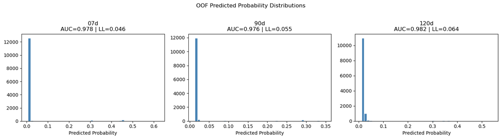

```python
print('\n' + '='*55)
print('📊 CROSS-VALIDATION RESULTS')
print('='*55)
print(f'{"Target":<30} {"AUC":>8} {"LogLoss":>10}')
print('-'*55)
for t in TARGETS:
    print(f'{t:<30} {results[t]["auc"]:>8.4f} {results[t]["logloss"]:>10.4f}')
print('='*55)

# OOF prediction distributions
fig, axes = plt.subplots(1, 3, figsize=(15, 4))
for i, t in enumerate(TARGETS):
    axes[i].hist(results[t]['oof'], bins=50, color='steelblue', edgecolor='white')
    axes[i].set_title(f'{t.split("_")[2]}d\nAUC={results[t]["auc"]:.3f} | LL={results[t]["logloss"]:.3f}')
    axes[i].set_xlabel('Predicted Probability')
plt.suptitle('OOF Predicted Probability Distributions', y=1.02)
plt.tight_layout()
plt.show()
```

### Feature Importance

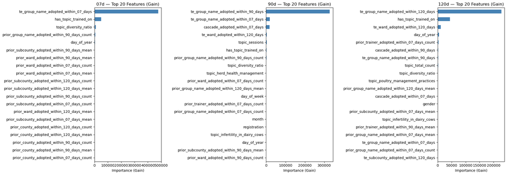

```python
# LightGBM feature importance
n_features_model = models[TARGETS[0]].n_features_in_
feature_names_model = feature_names[:n_features_model]

fig, axes = plt.subplots(1, 3, figsize=(20, 7))
for i, target in enumerate(TARGETS):
    model = models[target]

    # Build feature names including cascade columns added for this target
    if i == 0:
        names = feature_names.copy()
    elif i == 1:
        names = feature_names + [f'cascade_{TARGETS[0]}']
    else:
        names = feature_names + [f'cascade_{TARGETS[0]}', f'cascade_{TARGETS[1]}']

    imp = pd.Series(
        model.booster_.feature_importance(importance_type='gain'),
        index=names
    )
    imp = imp.sort_values(ascending=False).head(20)
    imp.plot(kind='barh', ax=axes[i], color='steelblue')
    axes[i].invert_yaxis()
    axes[i].set_title(f'{target.split("_")[2]}d — Top 20 Features (Gain)')
    axes[i].set_xlabel('Importance (Gain)')

plt.tight_layout()
plt.show()
```

```python
# Test predictions are already computed during training (stored in pred_dict)
# Just rename for clarity
test_preds = pred_dict

print('Test prediction summary:')
for target in TARGETS:
    p = test_preds[target]
    print(f'  {target}: mean={p.mean():.4f}  std={p.std():.4f}  min={p.min():.4f}  max={p.max():.4f}')
```

```
Test prediction summary:
  adopted_within_07_days: mean=0.1857  std=0.2139  min=0.0108  max=0.4554
  adopted_within_90_days: mean=0.0343  std=0.0655  min=0.0136  max=0.3164
  adopted_within_120_days: mean=0.0922  std=0.1058  min=0.0157  max=0.4033
```

```python
# Build submission — using exact column names from sample_sub
col_map = {
    'adopted_within_07_days':  {'auc': 'Target_07_AUC',  'll': 'Target_07_LogLoss'},
    'adopted_within_90_days':  {'auc': 'Target_90_AUC',  'll': 'Target_90_LogLoss'},
    'adopted_within_120_days': {'auc': 'Target_120_AUC', 'll': 'Target_120_LogLoss'},
}

submission = pd.DataFrame()
submission['ID'] = test_ids.values

for target, cols in col_map.items():
    probs = np.clip(test_preds[target], 0.001, 0.999)
    submission[cols['auc']] = probs
    submission[cols['ll']]  = probs

# Reorder to match sample_sub exactly
submission = submission[sample.columns]

print(f'Submission shape  : {submission.shape}')
print(f'Columns match     : {list(submission.columns) == list(sample.columns)}')
print(f'Any nulls         : {submission.isnull().any().any()}')
display(submission.head(10))

submission.to_csv('submission.csv', index=False)
print('\n✅ submission.csv saved!')
```

```
Submission shape  : (5621, 7)
Columns match     : True
Any nulls         : False
```

|  | ID | Target_07_AUC | Target_90_AUC | Target_120_AUC | Target_07_LogLoss | Target_90_LogLoss | Target_120_LogLoss |
| --- | --- | --- | --- | --- | --- | --- | --- |
| 0 | ID_LEG1GM | 0.455310 | 0.021146 | 0.246885 | 0.455310 | 0.021146 | 0.246885 |
| 1 | ID_1UKOKW | 0.010753 | 0.013609 | 0.015718 | 0.010753 | 0.013609 | 0.015718 |
| 2 | ID_U5H2YK | 0.010753 | 0.013609 | 0.019182 | 0.010753 | 0.013609 | 0.019182 |
| 3 | ID_55957A | 0.010753 | 0.013609 | 0.019182 | 0.010753 | 0.013609 | 0.019182 |
| 4 | ID_N1AC0A | 0.010753 | 0.013609 | 0.015718 | 0.010753 | 0.013609 | 0.015718 |
| 5 | ID_4R3SGT | 0.010753 | 0.013609 | 0.015718 | 0.010753 | 0.013609 | 0.015718 |
| 6 | ID_NVW38U | 0.010753 | 0.013609 | 0.017715 | 0.010753 | 0.013609 | 0.017715 |
| 7 | ID_15LAWX | 0.455310 | 0.021146 | 0.246885 | 0.455310 | 0.021146 | 0.246885 |
| 8 | ID_DPNOLZ | 0.455310 | 0.021095 | 0.246885 | 0.455310 | 0.021095 | 0.246885 |
| 9 | ID_GXO4MZ | 0.010753 | 0.013609 | 0.015707 | 0.010753 | 0.013609 | 0.015707 |

```
✅ submission.csv saved!
```